# 15.Statistics Introduction

Let's first start with some definitions that will come up in discussing different statistics topics.

Definition:

1. **Statistics** - The study of the collection, organization, analysis, and interpretation of data.

While this term may be commonly understood or known, it is worth formerly defining precisely what is meant by statistics. It is a broad field that encompasses many different aspects. While most of the time, it is thought of as a science, certain areas of statistics are more of an art form than hard science. With certain types of data, it takes quite a lot of experience to collect, organize, analyze, and interpret data in an accurate and meaningful way.

Definition:

1. **Population** - The entire collection of objects, measurements, observations, etc.

A population is an entire group being studied. Quite often, this is thought of as an infinitely large body, but nothing can indeed ever be infinitely large in practice. However, in certain situations, a group can be considered "large enough," by some simplifying assumptions, so that the group may be considered to behave as an infinitely large body.

Definition:

1. **Sample** - A representative subset of a population.

If a population is an infinitely large group, then a sample is a finite-sized group representing the population adequately. It is as if you have a population, and you remove a section of it to create a sample. For example, let's say that the entire student body at Louisiana Tech is the population; a sample might be this particular class of students. The whole student body is vast compared to the size of the class (thousands compared to tens). The argument could be made that this particular class is not a good representative group of the entire student body at Tech. In this case, the sample might be described as being inadequate or not large enough. Quite often, the population that a sample is taken from is known as the parent population. It's as if the sample is a child or product of the population. In practice, whenever any data is collected, it will be a sample and not a population. The term "a sample of data" comes from the fact that data collected will always be a sample in practice.

Definition:

1. **Random Variable** - A variable being measured.

There are two types of random variables.

- Discrete

Discrete random variables can only exist at discrete values. For example, the outcomes of a coin toss or six-sided die will be a discrete random variable. For the coin, there are only two options; heads or tails. A coin toss can't be a third heads and two-thirds tails or a quarter tails and three-quarters heads. It has to be either heads or tails. There are two discrete options. In the case of the six-sided die, there are six discrete options.

- Continuous

Continuous random variables can exist in states of an endless range of values. An example of a continuous random variable is the lifetime of a light bulb. A bulb's lifetime could be 1,000 hours, or it could be 2,000 hours or anywhere time in between those two. It is not constrained to a group of fixed values.

Definition:

1. **Distribution function** - A graphical or mathematical representation of a random variable.

Distribution functions are typically known by there graphical representation. The most common distribution function is a bell curve or normal distribution. The name bell comes from the fact that it resembles a bell. Though there are many different distribution functions, those functions can be symmetric or skewed in different manners. Some examples of skewed distributions may be seen [here](https://en.wikipedia.org/wiki/Skewness#/media/File:Relationship_between_mean_and_median_under_different_skewness.png). Their modality can also describe them. Modality (coming from the same root word as mode) is basically how many "peaks" the distribution has. Some examples may be seen [here](https://miro.medium.com/max/1400/0*m_Fd3Opt6L70LiYS.png).

Definition:

1. **Probability** - The chance of occurrence of an event.

Probability is a numeric value ranging from 0 to 1, although it is sometimes represented as a percentage or a ratio (i.e., 25% or 4:1 chance). If an event is sure to occur, then the probability $ P = 1 $. If an event is sure not to happen, then the probability $ P = 0 $. If event $ A $ and $ B $ are mutually exclusive (i.e., they cannot occur simultaneously, like the rolling of a die), then the probability $ P $ that event $ A $ or $ B $ occur is given by

$$ P \left( A\ or\ B \right) = P \left( A \right) + P \left( B \right) $$

That is to say, the probability of event $ A $ or $ B $ occurring is the probability of event $ A $ happening plus the probability of event $ B $ occurring. An example of this would be rolling a 3 or 4 on a six-sided die. The chance of rolling a 3 is 1 in 6. The likelihood of rolling a 4 is 1 in 6. The possibility of rolling a 3 or 4 is then 2 in 6 or 1 in 3. If event $ A $ and $ B $ are independent of one another, then the probability that both will occur is given by

$$ P\left(AB\right) = P\left(A\right)\cdot P\left(B\right) $$

This type of probability would be for the case of simultaneously rolling a three on a six sided die and flipping heads on a coin. The die and coin are independent of one another. The die doesn't affect the coin, and the coin doesn't affect the die. The probability of rolling a 3 is 1 in 6. The probability of flipping heads is 1 in 2. So the probability of simultaneously rolling a 3 and flipping heads is $ \frac{1}{6}\cdot \frac{1}{2} = \frac{1}{12} $.

## Example: Birthday Paradox

**Given and Required:**

What is the probability $P$ that at least two people share a birthday in a group of $n$ people?

**Solution:**

This problem is known as the [birthday paradox](https://en.wikipedia.org/wiki/Birthday_problem) or birthday problem. It is described as a paradox because the resulting probability is often much different than most people intuitively think. Before developing a solution, a couple of simplifying assumptions may be made. Let's assume that we are only considering non-leap years (i.e., there are only 365 days in a year) and that each day of the year is equally likely to have a birthday. This type of distribution is known as a uniform distribution. The birthdays are uniformly distributed over the year.

For the sake of developing a solution, let's start with the simplest case, a group consisting of a single person ($n = 1$). The probability that the person will have the same birthday as someone else in the group (other than themselves, of course) is zero. There is no one else to share a birthday with, so there is no chance of a shared birthday or $P = 0$.

For a group consisting of two people ($n = 2$), the probability may be found by looking at the possible pairs of people. The likelihood that the first pair of people (the first and second person) will have the same birthday is $1$ in $365$ or approximately $0.002739$. Since there is only one pair of people, the probability of someone sharing a birthday in a group of two people is $1$ in $365$ or $P = \frac{1}{365}$.

For a group consisting of three people ($n = 3$), things aren't as straight forward. Let's give a number to each person in the group starting at one. So the first person is number 1, the second is number 2, and so forth. The possible pairs of people are (1, 2), (1, 3), and (2, 3). The chance of (1, 2) having the same birthday is $1$ in $365$. The chance of (1, 3) having the same birthday is also $1$ in $365$. Likewise, (2, 3) have a $1$ in $365$ chance of having the same birthday. The trouble arises when multiple pairs have the same birthday. The original question is only concerned if any two people share a birthday, not how many people share a birthday, or how many pairs share a birthday. A simpler way to think about the problem is the probability $P'$ that no one in a group shares a birthday. If the probability $P'$ that no one in a group shares a birthday is known, then the probability $P$ that at least two people in the group share a birthday is $P = 1 - P'$ because there are only two outcomes. There is either at least a pair that share a birthday or no one shares a birthday. Approaching the problem from this standpoint simplifies some things. The probability that person one does not share a birthday with anyone is $363$ in $365$. The probability that person two does not share a birthday with anyone is $364$ in $365$. It is $364$ here because the (1, 2) pair has already been accounted for in the probability of person 1. Finally, the probability that person three does not share a birthday with anyone has been accounted for in the probabilities of person one and two. Another way you can think of it is as if person three has a probability of $1$ of not sharing a birthday with anyone other then persons one and two since that probability has already been addressed. So the total probability that no one shares a birthday in the group is the product of the probabilities of the person one and person two or $P' = \frac{363}{365}\frac{364}{365} \approx 0.9918$. So the probability that at least two people in the group share a birthday is $P = 1 - P' = 1 - \frac{363}{365}\frac{364}{365} \approx 0.008204$.

Let's look at a group consisting of four people ($n = 4$), and then we can generalize the process. The same process as in the case of a group of three people will be used. The probability of no one sharing a birthday will first be found, then the probability of at least two people sharing a birthday will be determined. The probability that person one will not share a birthday is $362$ in $365$. For person 2, the probability is $363$ in $365$. For person 3, the probability is $364$ in $365$. Hopefully, by now, a pattern should be seen for the $i$-th person, the probability is $365 - (n - i)$ in $365$. The probability that no one in the group shares a birthday is then

$$ P' = \left(\frac{365 - \left(n - 1\right)}{365}\right)\left(\frac{365 - \left(n - 2\right)}{365}\right)\left(\frac{365 - \left(n - 3\right)}{365}\right)\cdots\left(\frac{365 - \left(n - n\right)}{365}\right) $$

Another way to write this is using the [Capital Pi notation](https://en.wikipedia.org/wiki/Multiplication#Capital_pi_notation). This is shown below.

$$ P' = \prod_{i=1}^{n} \frac{365 - \left(n - i\right)}{365} $$

Capital Pi notation works similar to [Capital Sigma notation](https://en.wikipedia.org/wiki/Summation#Capital-sigma_notation) but it is a series of products instead of a summation. The probability that at least two people share a birthday is then

$$ P = 1 - P' = 1 - \prod_{i=1}^{n} \frac{365 - \left(n - i\right)}{365} $$

This expression can be simplified into

$$ P = 1 - \prod_{i=1}^{n} \left( 1 - \frac{n - i}{365}\right) $$

This expression is shown below as a Python function.

```python
def birthday_paradox(n, days_in_year = 365):
    pp = 1
    for i in range(1, n + 1):
        pp *= (1 - (n - i)/days_in_year)
    return 1 - pp
```

The function may now be used to find the probability that a group of $n$ people has at least two people that share a birthday. For example, for our class size of 16 students, the probability that at least two people share a birthday is shown below.

```python
birthday_paradox(16) # Answer
```

```
0.2836040052528499
```

For there to be about a 50%-50% chance, it only takes 23 people.

```python
birthday_paradox(23)
```

```
0.5072972343239853
```

For there to be approximately a 95% chance, it takes 47 people.

```python
birthday_paradox(47)
```

```
0.9547744028332994
```

## Measure of Central Tendency

Several different metrics are used to measure the central tendency of a group. The most common is the mean. The mean of a sample is given by

$$ \bar x = \frac{x_1 + x_2 + \cdots + x_n}{n} = \sum_{i = 1}^{n} \frac{x_i}{n} $$

where $ n $ is the number of data points in the sample or data set. The mean of a sample is denoted by the variable of the sample with a bar over it. In the context of statistics, if a variable has a bar over it, it typically refers to the mean of that variable. The mean of a population with a finite number of data points $ N $ is given by

$$ \mu = \sum_{i=1}^{N} \frac{x_i}{N} $$

where $ N $ is the number of data points in the population. A definition for the mean of a population with an infinite number of data points will be provided later in this course. The finite population mean is very similar to the sample mean formula but with some minor notation changes. The main difference is the variable used to represent the finite population mean $ \mu $. $ \mu $ is always used to describe the population mean. In future calculations, it should be an immediate indicator to the viewer that if the $ \mu $ variable is used, it is referring to the population mean, and if a variable with a bar over it is used, it is referring to a sample.

Definition:

1. **Median** - The central value of data set.

The median may seem like a similar definition to that of the mean, but the median is simply the middle value of a data set. For example, if a data set contained values 1, 3, 8, 9, and 10, the median is 8, while the mean would be 6.2.

Definition:

1. **Mode** - The value of the variable that corresponds to the peak value of the probability of occurrence.

The mode is the value that is most likely to occur. There sometimes is not a mode to a data set.

## Measure of Dispersion

The most straightforward measure of dispersion is deviation. Deviation $ d $ of a particular data point $ i $ of a sample is given by

$$ d_i = x_i - \bar x$$

Deviation is simply the difference between the particular data point and the sample mean. It is a measure of how far a specific data point deviates from the group's mean or average value. The definition of random error of a single data point provided in previous lectures is a type of deviation. While this can be a useful metric, it is hard to compare deviations in samples of different magnitudes. For example, consider a sample with a mean of 10. One of the data points in that sample has a value of 12. That data point has a deviation of 2. Now consider a different sample with a mean of 100, and let's say that one of the data points in that sample has a value of 120. That data point has a deviation of 20, making one believe that it has a much larger deviation than the previous sample. However, percentage-wise, the two data points have the same amount of deviation. Taking the relative size of the sample is where the idea of standard deviation originates. Standard deviation is the measure of the deviation of all the data points in a group, and it is normalized in such a way that samples of different magnitudes may be compared. The standard deviation of a sample $ S $ is given by

$$ S = \sqrt{\sum_{i=1}^n \frac{\left(x_i - \bar x\right)^2}{n-1}} $$

The standard deviation of a sample is the average of the deviations of all the data points. Although this is not 100% true, it is helpful to think about it in this way. If it were truly the deviations' mean, then the denominator would be $ n $ and not $ n - 1$. For a full and thorough explanation why $ n - 1 $ is used see [here](https://towardsdatascience.com/why-sample-variance-is-divided-by-n-1-89821b83ef6d) (WARNING!!! Heavy statistics is used). The standard deviation of a finite population $ \sigma $ is given by

$$ \sigma = \sqrt{\sum_{i = 1}^N \frac{\left( x_i - \mu \right)^2}{N}} $$

Note the use of $ \sigma $ here. Just like the use of $ \mu $ should tell the viewer that a population is being described, the use of $ \sigma $ should be an indicator to the viewer. Variance is another measure of dispersion. The variance is the square of the standard deviation of a group. There is no particular variable or character to denote variance, as in standard deviation and mean. The variance is typically written as $ S^2 $ or $ \sigma^2 $ for a sample and population, respectively.

## Histograms

Definition:

1. **Histogram** - A graphical method to represent the occurrence of data.

While creating a histogram in Python has already been discussed in this course, it is useful to know how a histogram might be made by hand. The steps below outline the process of creating a histogram.

1. Determine the number of data points in the data set $ n $.
2. Determine the range $ R $ for the entire data set. The range is the largest value in the data set minus the smallest value.
3. Divide the range $ R $ by the number of bins $ B $ that you want in your histogram. Table 1 below provides an approximate guideline for dividing your data set into a reasonable number of bins.

Table 1: Histogram Bin Number Selection Guide

| Number of data points, $ n $ | Number of bins, $ B $ |
| --- | --- |
| $\lt 50$ | $5-7$ |
| $50-100$ | $6-10$ |
| $100-250$ | $7-12$ |
| $\gt 250$ | $10-20$ |

4. Determine the bin width $ W $. A convenient formula is $ W = R / B $. The bin width is the width of each of the bars on your histogram. You may want to round the value of $ W $ off to make your histogram more clear.
5. Choose the starting point (a rounded-off value near the minimum value in the data set) and determine the numerical value where each of the divisions will occur based on the width $ W $ of each bin.
6. Count the number of data points in each division (whose width is $ W $).
7. Create the histogram. The histogram creation may be done in Excel as a bar chart.

## Example: Exam Grades

**Given and Required:**

For the exam grades in the file exam_grades.csv, create a histogram with an appropriate bin size.

**Solution:**

The file is saved locally on the computer at the following location. Note that this may change if you save the exam_grades.csv file in a different place. If that is the case, change the `filename` variable to the file's file path location.

```python
filename = 'datasets/exam_grades.csv'
```

Any needed libraries are imported below.

```python
import matplotlib.pyplot as plt
```

The exam data file may then be opened and read into a variable.

```python
file = open(filename).read().strip()
```

The `file` variable may then split into a list where each element is a row of the file.

```python
rows = file.split('\n')
```

The first row of the file may be removed since it is not data but a header that describes the data.

```python
rows.pop(0)
```

```
'exam grades'
```

Each element of the list `rows` is a string. To do any arithmetic with these values, they must first be converted into a numeric value. This may be done in Python by [list comprehension](https://www.pythonforbeginners.com/basics/list-comprehensions-in-python).

```python
data = [int(r) for r in rows]
```

Before the plot is created, the number of bins is determined by using Table 1. The number of data points must first be found.

```python
n = len(data)
print(n)
```

```
466
```

Since the number of data points is greater than 250, the number of bins to be used should be between 10 and 20. 466 is nearly double 250, so let's start with 20 bins and go down if necessary.

```python
B = 20
```

Now the histogram may be created.

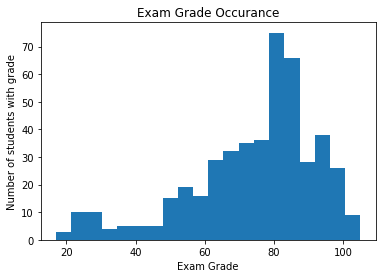

```python
fig, ax = plt.subplots(1, 1)

ax.hist(data, bins = B)

ax.set_title('Exam Grade Occurance')
ax.set_xlabel('Exam Grade')
ax.set_ylabel('Number of students with grade')

plt.show()
```

In practice, the number of bins can be adjusted to see if a different number of bins makes the histogram more appealing.

Download Complete Python Script Here